# Exp6 Analysis

Mrudula

29 January,2021

**This document contains the result memo of Experiment 6 aimed to explore overshadowing in a CL paradigm. It builds on from the design used in Experiment 5 that showed success in manipulating saliency. HEnce, this experiment goes back to exploring overshadowing in depth by introducing learn and test trials with a 90:10 and 80:20 contingency ratio. In this design the target position is no longer dependent on the letters and is presented centrally. The task also is now changed to odd/even instead of 5 and 8.**

Loading the relevant libraries and the dataset

### Data preparation and cleaning

- Removing unnecessary columns
- Preparing the RT trial
- Creating a column for Accuracy and Error Rate

### Descriptives

Summary of the overall Reaction Time, accuracy and Error Rate

Mean RT

| Min. | 1st Qu. | Median | Mean | 3rd Qu. | Max. |
| --- | --- | --- | --- | --- | --- |
| 0.675 | 455 | 539.7 | 570.2 | 638 | 11708 |

Accuracy

| 0 | 1 |
| --- | --- |
| 1688 | 27431 |

Percentage of errors

| 0 | 1 |
| --- | --- |
| 5.797 | 94.2 |

Removing the outliers and farouts

```
## [1] 1688
```

```
## [1] 3365
```

```
## [1] 4231
```

Summary of RT after removing Farouts

| Min. | 1st Qu. | Median | Mean | 3rd Qu. | Max. | NA’s |
| --- | --- | --- | --- | --- | --- | --- |
| 300.1 | 473 | 548.2 | 575.1 | 640.9 | 2080 | 3365 |

Summary of RT after removing Outliers

| Min. | 1st Qu. | Median | Mean | 3rd Qu. | Max. | NA’s |
| --- | --- | --- | --- | --- | --- | --- |
| 300.1 | 469.5 | 543 | 559.5 | 628 | 1583 | 4231 |

## ANALYSES

### 1. Validity Manipulation check - Learn trials

Valid trials are significantly faster than invalid trials with a mean difference of 17ms (farouts) and 17ms for outliers.

Table containing means of valid and invalid learn trials, farouts excluded

| Validity | RT_ifo |
| --- | --- |
| invalid | 588.1 |
| valid | 571 |

t test showing differences between valid and invalid trials (continued below)

| Test statistic | df | P value | Alternative hypothesis |
| --- | --- | --- | --- |
| 4.811 | 69 | 8.509e-06 * * * | two.sided |

| mean of the differences |
| --- |
| 17.14 |

Table containing means of valid and invalid learn trials, outliers excluded

| Validity | RT_io |
| --- | --- |
| invalid | 573.3 |
| valid | 555.6 |

t test showing differences between valid and invalid trials-excluding outliers (continued below)

| Test statistic | df | P value | Alternative hypothesis |
| --- | --- | --- | --- |
| 5.949 | 69 | 1.003e-07 * * * | two.sided |

| mean of the differences |
| --- |
| 17.64 |

### 2. Saliency Manipulation Check

This analysis checks whether the saliency manipulation worked by comapring the RT between trials where the number appeared in salient letters position vs non salient letter’s position.

```
  1. Farouts: It is almost significant(t > 1, p = 0.12) with a the mean difference is 17ms.
  2. Outliers: It is significant with a mean difference of 22ms
```

t test result for saliency manipulation (continued below)

| Test statistic | df | P value | Alternative hypothesis |
| --- | --- | --- | --- |
| 1.534 | 68 | 0.1296 | two.sided |

| mean of the differences |
| --- |
| 17.3 |

t test result for saliency manipulation, outliers (continued below)

| Test statistic | df | P value | Alternative hypothesis |
| --- | --- | --- | --- |
| 2.382 | 68 | 0.02 * | two.sided |

| mean of the differences |
| --- |
| 22.24 |

### 3. Interaction of Validity x Saliency in test trials

This analysis is the main one concerning overshadowing.

[output not shown]

- **ANOVA**:

  | Effect | DFn | DFd | SSn | SSd | F | p | p<.05 | ges |
  | --- | --- | --- | --- | --- | --- | --- | --- | --- |
  | (Intercept) | 1 | 69 | 93504677 | 1027637 | 6278 | 1.715e-69 | * | 0.9865 |
  | Validity | 1 | 69 | 5165 | 105309 | 3.384 | 0.07012 |  | 0.004016 |
  | Saliency | 1 | 69 | 639.2 | 66376 | 0.6645 | 0.4178 |  | 0.0004988 |
  | Validity:Saliency | 1 | 69 | 630.7 | 81575 | 0.5334 | 0.4676 |  | 0.0004921 |

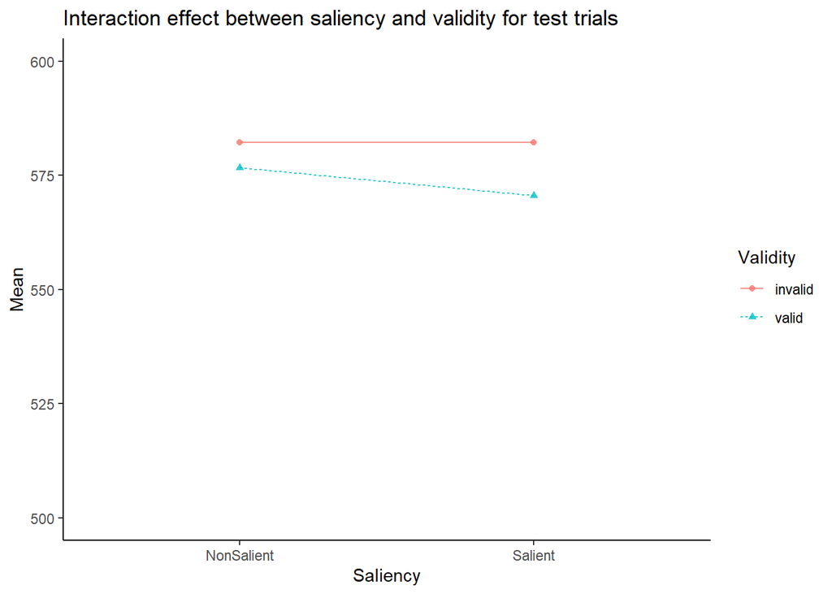

| Saliency | N | Mean | SD | FLSD |
| --- | --- | --- | --- | --- |
| NonSalient | 70 | 5.589 | 48.65 | 16.4 |
| Salient | 70 | 11.59 | 55.22 | 16.4 |

t test for validity effect for salient trials, farouts

| Test statistic | df | P value | Alternative hypothesis | mean of the differences |
| --- | --- | --- | --- | --- |
| 1.756 | 69 | 0.0835 | two.sided | 11.59 |

- **ANOVA**:

  | Effect | DFn | DFd | SSn | SSd | F | p | p<.05 | ges |
  | --- | --- | --- | --- | --- | --- | --- | --- | --- |
  | (Intercept) | 1 | 69 | 88908178 | 771385 | 7953 | 5.317e-73 | * | 0.9897 |
  | Validity | 1 | 69 | 9207 | 52996 | 11.99 | 0.0009241 | * | 0.009825 |
  | Saliency | 1 | 69 | 53.04 | 41242 | 0.08873 | 0.7667 |  | 5.716e-05 |
  | Validity:Saliency | 1 | 69 | 328.4 | 62202 | 0.3643 | 0.5481 |  | 0.0003538 |

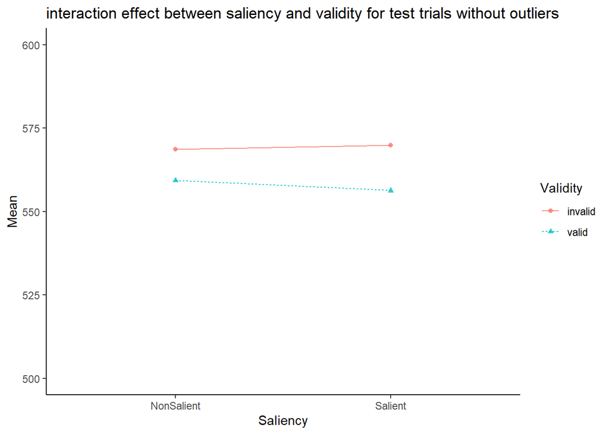

| Saliency | N | Mean | SD | FLSD |
| --- | --- | --- | --- | --- |
| NonSalient | 70 | 9.302 | 36.2 | 14.32 |
| Salient | 70 | 13.63 | 45.04 | 14.32 |

t test for validity effect for salient trials, outliers

| Test statistic | df | P value | Alternative hypothesis | mean of the differences |
| --- | --- | --- | --- | --- |
| 2.533 | 69 | 0.0136 * | two.sided | 13.63 |

Plots to show these effects.

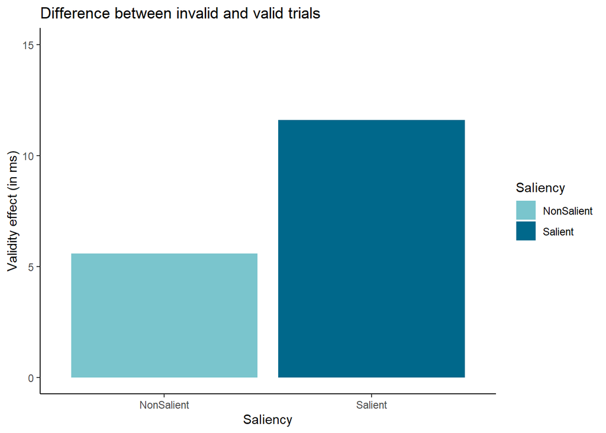

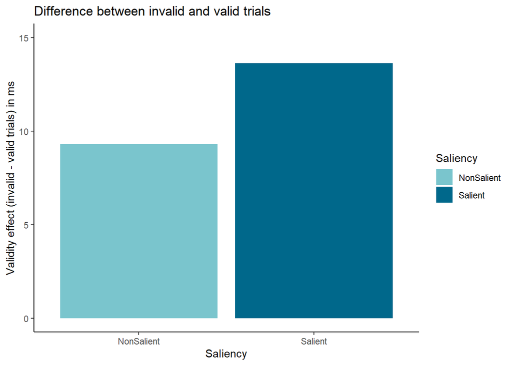

### 4. Error Rate

The Error Rate analysis shows the exact expected trend where the difference in error rate is highest when the trials are salient letters compared to when they are non salient. Both the main effects of Validity and Saliency are significant and the interaction is also significant.

Maybe this could throw more light on expected associations and quick responses leading to errors - can it be concluded that learning and overshadowing was successful based on error rates??

- **ANOVA**:

  | Effect | DFn | DFd | SSn | SSd | F | p | p<.05 | ges |
  | --- | --- | --- | --- | --- | --- | --- | --- | --- |
  | (Intercept) | 1 | 69 | 1.29 | 0.8903 | 99.98 | 4.685e-15 | * | 0.4477 |
  | Saliency | 1 | 69 | 0.01436 | 0.1759 | 5.633 | 0.02041 | * | 0.008944 |
  | Validity | 1 | 69 | 0.03226 | 0.2205 | 10.09 | 0.002227 | * | 0.01987 |
  | Saliency:Validity | 1 | 69 | 0.02811 | 0.3047 | 6.365 | 0.01395 | * | 0.01735 |

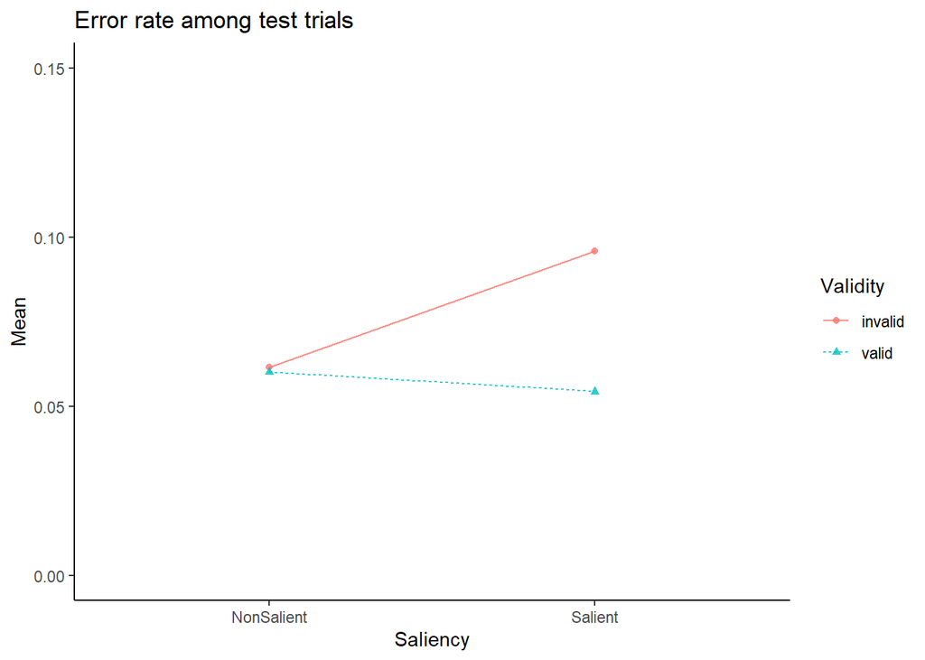

### 5. Inverse Efficiency scores

```r
## create a df that contains both Errorrate and RT

Exp6test <- Exp6data %>%
  subset(Condition == "test")

Exp6agg_IES <- aggregate(Exp6test[,c("RT_ifo","ErrorRate")], by = list(participant = Exp6test$participant,
                                                                       Validity = Exp6test$Validity,
                                                                       Saliency = Exp6test$Saliency), mean,na.rm = TRUE)

Exp6agg_IES$IES <- Exp6agg_IES$RT_ifo/(1-Exp6agg_IES$ErrorRate)

anova_t_IES <- ezANOVA(data = Exp6agg_IES,
        dv = IES,
        wid = participant,
        within = .(Saliency,Validity),
        detailed = TRUE)
panderOptions('table.split.table',300)
pander(anova_t_IES, style = 'rmarkdown', caption = "ANOVA results: using IES", split.table = "Inf", missing = NA)
```

- **ANOVA**:

  | Effect | DFn | DFd | SSn | SSd | F | p | p<.05 | ges |
  | --- | --- | --- | --- | --- | --- | --- | --- | --- |
  | (Intercept) | 1 | 69 | 109144612 | 1520506 | 4953 | 5.547e-66 | * | 0.9795 |
  | Saliency | 1 | 69 | 5810 | 172785 | 2.32 | 0.1323 |  | 0.002539 |
  | Validity | 1 | 69 | 50011 | 288325 | 11.97 | 0.000932 | * | 0.02145 |
  | Saliency:Validity | 1 | 69 | 20458 | 300382 | 4.699 | 0.03363 | * | 0.008885 |

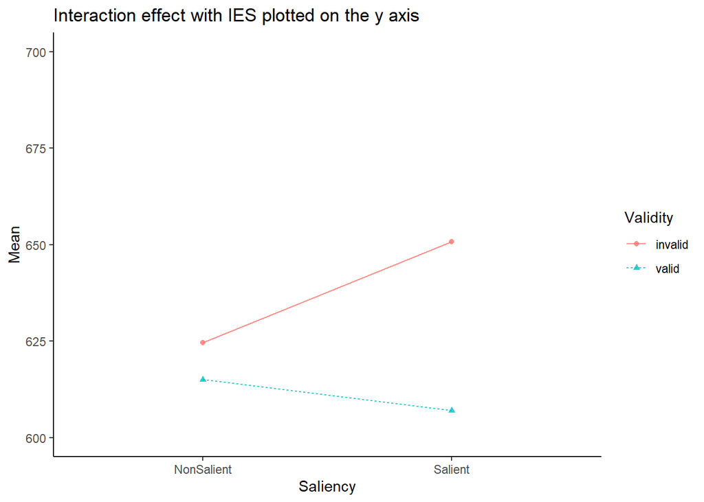

```r
ezPlot(data = Exp6agg_IES,
        dv = IES,
        wid = participant,
        within = .(Saliency,Validity),
       split = Validity, x = Saliency, do_bars = FALSE)+theme_classic()+ylim(600,700)+
  ggtitle("Interaction effect with IES plotted on the y axis")
```

```r
IESinterplot <- ggplot(Exp6agg_IES, aes(x=Saliency, y=IES,color = Validity))+
    geom_line(aes(group = Validity, linetype = Validity),size = 1,stat = "summary", fun = "mean",)+
    geom_point(stat = "summary", fun = "mean", aes(shape = Validity))+ylim(500,600)+
  scale_color_manual(values = c("deepskyblue4","cadetblue3"))+
  theme_classic()+ylab("IES (in ms)")+ggtitle("Interaction of Validity and Saliency")
#ggsave(filename = here("Figures","IESinterplot_fo.png"),IESinterplot)

meanIES <- ezStats(data = Exp6agg_IES,
        dv = IES,
        wid = participant,
        within_full = .(Saliency,Validity),
        within = .(Saliency),
        diff = .(Validity),
        reverse_diff = TRUE)
pander(meanIES, style = "rmarkdown", caption = "Mean IES score validity effect")
```

Mean IES score validity effect

| Saliency | N | Mean | SD | FLSD |
| --- | --- | --- | --- | --- |
| NonSalient | 70 | 9.634 | 79.02 | 31.46 |
| Salient | 70 | 43.82 | 104 | 31.46 |

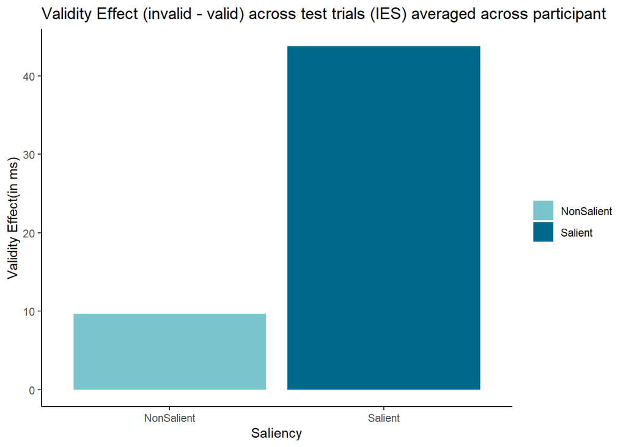

```r
ggplot(data = meanIES, aes(x = Saliency, y = Mean, fill = Saliency))+scale_fill_manual(values = c("cadetblue3","deepskyblue4"))+
  geom_bar(stat = "identity")+
  theme_classic()+
  ylab("Validity Effect(in ms)")+theme(legend.title = element_blank())+
  ggtitle("Validity Effect (invalid - valid) across test trials (IES) averaged across participant")
```